# R Notebook

# Laboratorio 2, ggplot y dplyr

## Carga librerías

```r
library(dplyr)
library(ggplot2)
library(lubridate)
```

## Carga de archivos

```r
DataBicis <- read.csv('dataset.csv')
DataBicis
```

| instant | dteday | season | yr | mnth | hr | holiday | weekday | workingday | weathersit | temp | atemp | hum | windspeed | casual | registered | cnt |
| --- | --- | --- | --- | --- | --- | --- | --- | --- | --- | --- | --- | --- | --- | --- | --- | --- |
| 1 | 2011-01-01 | 1 | 0 | 1 | 0 | 0 | 6 | 0 | 1 | 0.24 | 0.2879 | 0.81 | 0.0000 | 3 | 13 | 16 |
| 2 | 2011-01-01 | 1 | 0 | 1 | 1 | 0 | 6 | 0 | 1 | 0.22 | 0.2727 | 0.80 | 0.0000 | 8 | 32 | 40 |
| 3 | 2011-01-01 | 1 | 0 | 1 | 2 | 0 | 6 | 0 | 1 | 0.22 | 0.2727 | 0.80 | 0.0000 | 5 | 27 | 32 |
| 4 | 2011-01-01 | 1 | 0 | 1 | 3 | 0 | 6 | 0 | 1 | 0.24 | 0.2879 | 0.75 | 0.0000 | 3 | 10 | 13 |
| 5 | 2011-01-01 | 1 | 0 | 1 | 4 | 0 | 6 | 0 | 1 | 0.24 | 0.2879 | 0.75 | 0.0000 | 0 | 1 | 1 |
| 6 | 2011-01-01 | 1 | 0 | 1 | 5 | 0 | 6 | 0 | 2 | 0.24 | 0.2576 | 0.75 | 0.0896 | 0 | 1 | 1 |
| 7 | 2011-01-01 | 1 | 0 | 1 | 6 | 0 | 6 | 0 | 1 | 0.22 | 0.2727 | 0.80 | 0.0000 | 2 | 0 | 2 |
| 8 | 2011-01-01 | 1 | 0 | 1 | 7 | 0 | 6 | 0 | 1 | 0.20 | 0.2576 | 0.86 | 0.0000 | 1 | 2 | 3 |
| 9 | 2011-01-01 | 1 | 0 | 1 | 8 | 0 | 6 | 0 | 1 | 0.24 | 0.2879 | 0.75 | 0.0000 | 1 | 7 | 8 |
| 10 | 2011-01-01 | 1 | 0 | 1 | 9 | 0 | 6 | 0 | 1 | 0.32 | 0.3485 | 0.76 | 0.0000 | 8 | 6 | 14 |

[output cut: 990 more lines]

## Preguntas

### 1. Cree un conjunto de columnas nuevas: día, mes, año, hora y minutos a partir de la comlumna datetime, para esto investigue como puede “desarmar” la variable datetime utilizando lubridate y mutate.

```r
fechas <- DataBicis %>%
  mutate(
    minutos = hr*60,
    dia = day(dteday),
    mes = month(dteday),
    anio = year(dteday)
  )
fechas
```

| instant | dteday | season | yr | mnth | hr | holiday | weekday | workingday | weathersit | temp | atemp | hum | windspeed | casual | registered | cnt | minutos | dia | mes | anio |
| --- | --- | --- | --- | --- | --- | --- | --- | --- | --- | --- | --- | --- | --- | --- | --- | --- | --- | --- | --- | --- |
| 1 | 2011-01-01 | 1 | 0 | 1 | 0 | 0 | 6 | 0 | 1 | 0.24 | 0.2879 | 0.81 | 0.0000 | 3 | 13 | 16 | 0 | 1 | 1 | 2011 |
| 2 | 2011-01-01 | 1 | 0 | 1 | 1 | 0 | 6 | 0 | 1 | 0.22 | 0.2727 | 0.80 | 0.0000 | 8 | 32 | 40 | 60 | 1 | 1 | 2011 |
| 3 | 2011-01-01 | 1 | 0 | 1 | 2 | 0 | 6 | 0 | 1 | 0.22 | 0.2727 | 0.80 | 0.0000 | 5 | 27 | 32 | 120 | 1 | 1 | 2011 |
| 4 | 2011-01-01 | 1 | 0 | 1 | 3 | 0 | 6 | 0 | 1 | 0.24 | 0.2879 | 0.75 | 0.0000 | 3 | 10 | 13 | 180 | 1 | 1 | 2011 |
| 5 | 2011-01-01 | 1 | 0 | 1 | 4 | 0 | 6 | 0 | 1 | 0.24 | 0.2879 | 0.75 | 0.0000 | 0 | 1 | 1 | 240 | 1 | 1 | 2011 |
| 6 | 2011-01-01 | 1 | 0 | 1 | 5 | 0 | 6 | 0 | 2 | 0.24 | 0.2576 | 0.75 | 0.0896 | 0 | 1 | 1 | 300 | 1 | 1 | 2011 |
| 7 | 2011-01-01 | 1 | 0 | 1 | 6 | 0 | 6 | 0 | 1 | 0.22 | 0.2727 | 0.80 | 0.0000 | 2 | 0 | 2 | 360 | 1 | 1 | 2011 |
| 8 | 2011-01-01 | 1 | 0 | 1 | 7 | 0 | 6 | 0 | 1 | 0.20 | 0.2576 | 0.86 | 0.0000 | 1 | 2 | 3 | 420 | 1 | 1 | 2011 |
| 9 | 2011-01-01 | 1 | 0 | 1 | 8 | 0 | 6 | 0 | 1 | 0.24 | 0.2879 | 0.75 | 0.0000 | 1 | 7 | 8 | 480 | 1 | 1 | 2011 |
| 10 | 2011-01-01 | 1 | 0 | 1 | 9 | 0 | 6 | 0 | 1 | 0.32 | 0.3485 | 0.76 | 0.0000 | 8 | 6 | 14 | 540 | 1 | 1 | 2011 |

[output cut: 990 more lines]

### 2. ¿Qué mes es el que tiene la mayor demanda? Muestre una tabla y una gráfica

```r
MaxMes <- DataBicis %>%
  group_by(mnth) %>%
  summarise(totalesmes = sum(cnt))
MaxMes
```

| mnth | totalesmes |
| --- | --- |
| 1 | 134933 |
| 2 | 151352 |
| 3 | 228920 |
| 4 | 269094 |
| 5 | 331686 |
| 6 | 346342 |
| 7 | 344948 |
| 8 | 351194 |
| 9 | 345991 |
| 10 | 322352 |

[output cut: 2 more lines]

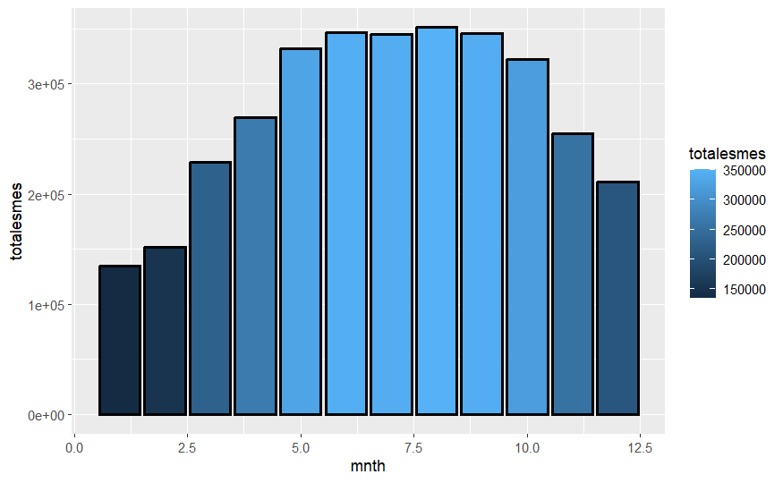

```r
ggplot(MaxMes, aes(x = mnth, y = totalesmes, fill = totalesmes)) +
  geom_bar(stat = 'identity', col = 'black', lwd = 1)
```

Tanto en la tabla como en la gráfica, se puede ver que el mes que más rentas tiene es agosto. Se puede ver también que junio, julio y septiembre también tienen ventas similares

### 3. ¿Qué rango de hora es la de mayor demanda? Muestre una tabla y una gráfica

```r
MaxHora <- DataBicis %>%
  group_by(hr) %>%
  summarise(totaleshr = sum(cnt))
MaxHora
```

| hr | totaleshr |
| --- | --- |
| 0 | 39130 |
| 1 | 24164 |
| 2 | 16352 |
| 3 | 8174 |
| 4 | 4428 |
| 5 | 14261 |
| 6 | 55132 |
| 7 | 154171 |
| 8 | 261001 |
| 9 | 159438 |

[output cut: 14 more lines]

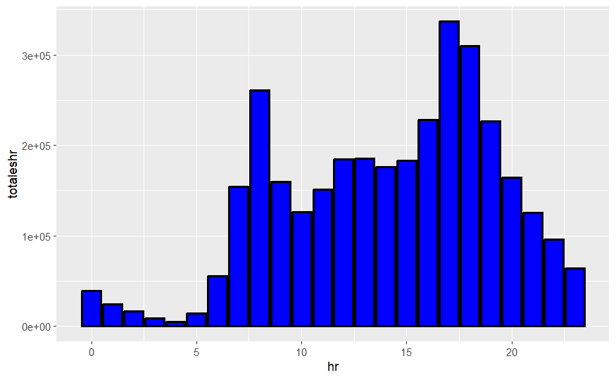

```r
ggplot(MaxHora, aes(x = hr, y = totaleshr)) +
  geom_bar(stat = 'identity', col = 'black', lwd = 1, fill = 'blue')
```

Tanto en la tabla como en la gráfica se observa que entre las 17 y 18 horas está el máximo de rentas.

### 4. ¿Qué temporada es la mas alta? Muestre una tabla

```r
MaxSsn <- DataBicis %>%
  group_by(season) %>%
  summarise(totalesssn = sum(cnt))
MaxSsn
```

| season | totalesssn |
| --- | --- |
| 1 | 471348 |
| 2 | 918589 |
| 3 | 1061129 |
| 4 | 841613 |

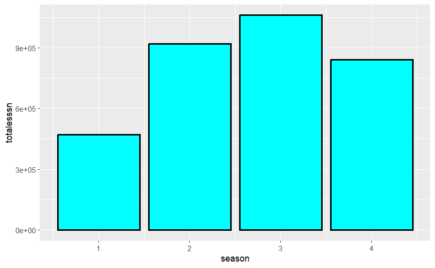

```r
ggplot(MaxSsn, aes(x = season, y = totalesssn)) +
  geom_bar(stat = 'identity', col = 'black', lwd = 1, fill = 'cyan')
```

Tanto en la gráfica como en la tabla se puede ver que el máximo de rentas está en la estación 3

### 5. ¿A que temperatura disminuye la demanda? Muestre una gráfica para analizar y dar su respuesta

```r
DatosTemp <- DataBicis %>%
  group_by(temp)%>%
  summarise(RentaTotalT = sum(cnt), AvgRenta = mean(cnt))
DatosTemp
```

| temp | RentaTotalT | AvgRenta |
| --- | --- | --- |
| 0.02 | 712 | 41.88235 |
| 0.04 | 570 | 35.62500 |
| 0.06 | 672 | 42.00000 |
| 0.08 | 480 | 28.23529 |
| 0.10 | 2514 | 49.29412 |
| 0.12 | 4440 | 58.42105 |
| 0.14 | 7605 | 55.10870 |
| 0.16 | 15083 | 65.57826 |
| 0.18 | 9318 | 60.11613 |
| 0.20 | 28230 | 79.74576 |

[output cut: 40 more lines]

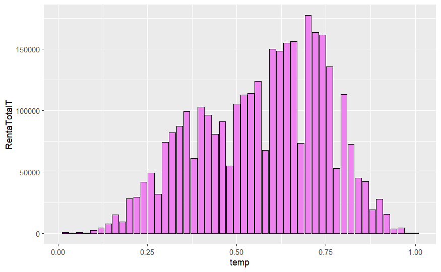

```r
ggplot(data = DatosTemp, aes(x = temp, y = RentaTotalT))+
  geom_bar(stat = 'identity', col = 'black', lwd = 0.4, fill = 'violet')
```

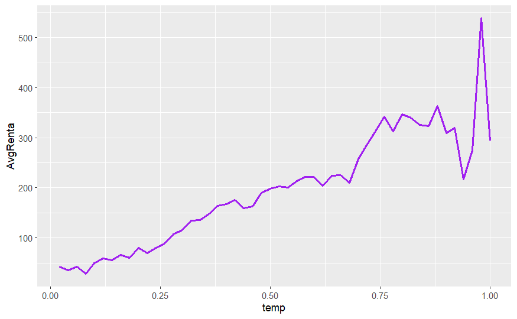

```r
ggplot(data = DatosTemp, aes(x = temp, y = AvgRenta), fill = 'violet')+
  geom_line(stat = 'identity', col = 'purple', lwd = 1)
```

A través de las gráficas presentadas, se puede observar que las rentas disminuyen a menor temperatura.

### 6. ¿A que humedad disminuye la demanda? Muestre una gráfica para analizar y dar su respuesta.

```r
DatosHum <- DataBicis %>%
  group_by(hum)%>%
  summarise(RentaTotalH = sum(cnt), AvgRentaH = mean(cnt))
DatosHum
```

| hum | RentaTotalH | AvgRentaH |
| --- | --- | --- |
| 0.00 | 623 | 28.31818 |
| 0.08 | 77 | 77.00000 |
| 0.10 | 107 | 107.00000 |
| 0.12 | 29 | 29.00000 |
| 0.13 | 17 | 17.00000 |
| 0.14 | 38 | 19.00000 |
| 0.15 | 292 | 73.00000 |
| 0.16 | 2416 | 241.60000 |
| 0.17 | 3404 | 340.40000 |
| 0.18 | 3301 | 330.10000 |

[output cut: 79 more lines]

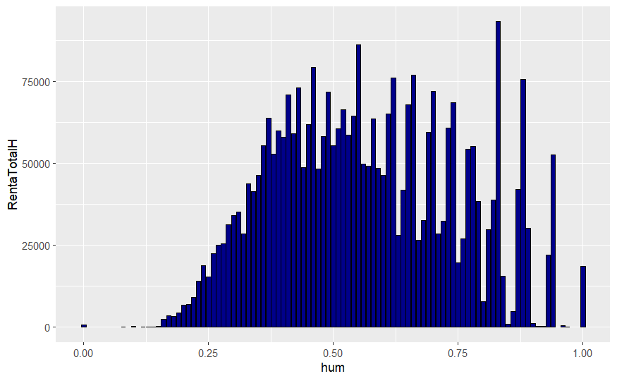

```r
ggplot(data = DatosHum, aes(x = hum, y = RentaTotalH))+
  geom_bar(stat = 'identity', col = 'black', lwd = 0.5, fill = 'darkblue')
```

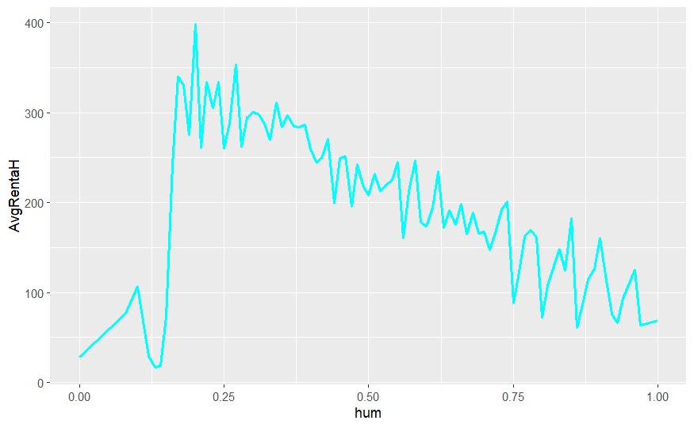

```r
ggplot(data = DatosHum, aes(x = hum, y = AvgRentaH))+
  geom_line(stat = 'identity', col = 'cyan', lwd = 1)
```

a través de las gráficas presentadas, es notorio que las rentas disminuyen a medida que aumenta la humedad. El máximo de rentas promedio está cuando la humedad es alrededor de 0.25

### 7. ¿Que condiciones climáticas serian ideales para nuestra demanda? (considere una función de densidad bivariable para la temperatura y la humedad)

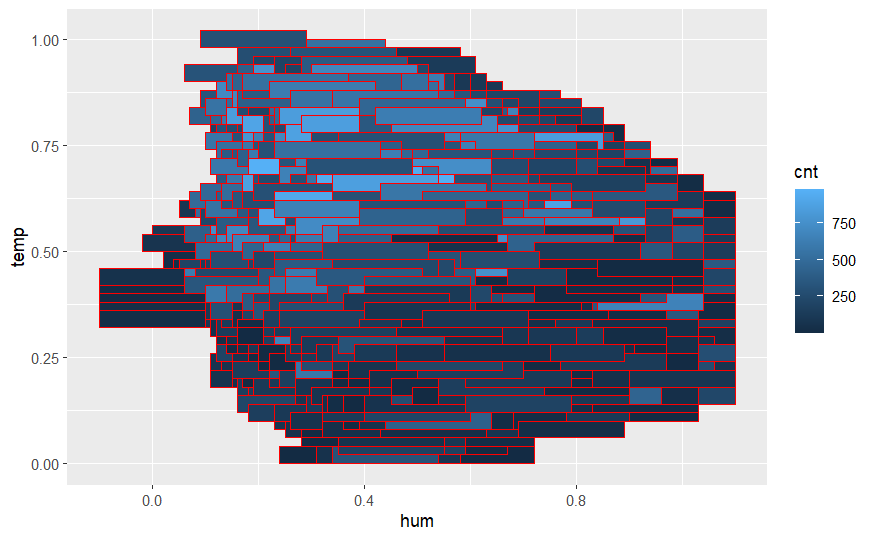

```r
ggplot(data = DataBicis, aes(x = hum, y = temp, fill = cnt))+
  geom_tile(width = 0.2, height = 0.04, alpha = 1, col = 'red')
```

En la gráfica, puede observarse que las mayores rentas están en temperaturas altas (alrededor de 0.75), y humedades bajas (alrededor de 0.3)

### 8. Mueste una gráfica de la densidad de rentas.

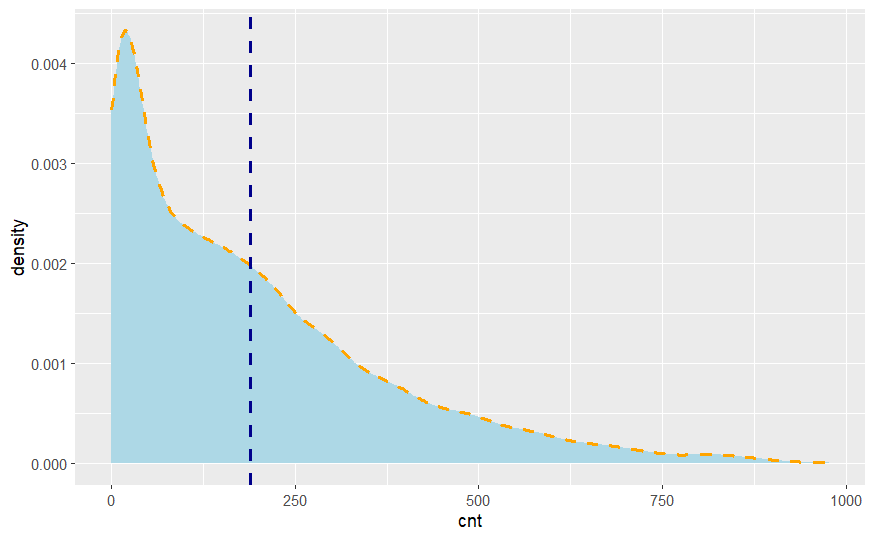

```r
ggplot(data = DataBicis, aes(x = cnt))+
  geom_density(stat = 'density', lwd = 1, col = 'orange', fill = 'lightblue', linetype = 'dashed')+
  geom_vline(aes(xintercept = mean(cnt)), col = 'darkblue', lwd = 1, linetype = 'dashed')
```

### 9. ¿En promedio de personas que rentan bicicletas y están registradas?

```r
PromedioNeto <- as.integer(mean(DataBicis$registered))
PromedioNeto
```

```
[1] 153
```

```r
PromedioMes <- DataBicis %>%
  group_by(mnth)%>%
  summarise(prommes = as.integer(mean(registered)))
PromedioMes
```

| mnth | prommes |
| --- | --- |
| 1 | 85 |
| 2 | 101 |
| 3 | 125 |
| 4 | 144 |
| 5 | 172 |
| 6 | 189 |
| 7 | 179 |
| 8 | 189 |
| 9 | 191 |
| 10 | 180 |

[output cut: 2 more lines]

```r
PromedioSsn <- DataBicis %>%
  group_by(season)%>%
  summarise(promssn = as.integer(mean(registered)))
PromedioSsn
```

| season | promssn |
| --- | --- |
| 1 | 96 |
| 2 | 162 |
| 3 | 185 |
| 4 | 168 |

### 10. Determine la mediana de personas que rentan bicicletas y no están registradas.

```r
PromedioNetoU <- as.integer(median(DataBicis$casual))
PromedioNetoU
```

```
[1] 17
```

```r
PromedioMesU <- DataBicis %>%
  group_by(mnth)%>%
  summarise(prommesU = as.integer(median(casual)))
PromedioMesU
```

| mnth | prommesU |
| --- | --- |
| 1 | 4 |
| 2 | 5 |
| 3 | 13 |
| 4 | 20 |
| 5 | 33 |
| 6 | 37 |
| 7 | 40 |
| 8 | 38 |
| 9 | 28 |
| 10 | 22 |

[output cut: 2 more lines]

```r
PromedioSsnU <- DataBicis %>%
  group_by(season)%>%
  summarise(promssnu = as.integer(median(casual)))
PromedioSsnU
```

| season | promssnu |
| --- | --- |
| 1 | 5 |
| 2 | 27 |
| 3 | 36 |
| 4 | 14 |

### 11. Deterimne la renta total, renta promedio por cada tipo de estación.

```r
DatosSsn <- DataBicis %>%
  group_by(season) %>%
  summarise(totales = sum(cnt), promedios = as.integer(mean(cnt)))
DatosSsn
```

| season | totales | promedios |
| --- | --- | --- |
| 1 | 471348 | 111 |
| 2 | 918589 | 208 |
| 3 | 1061129 | 236 |
| 4 | 841613 | 198 |

### 12. Determine y muestre una gráfica de barras la cantidad de rentas por tipo de temporada.

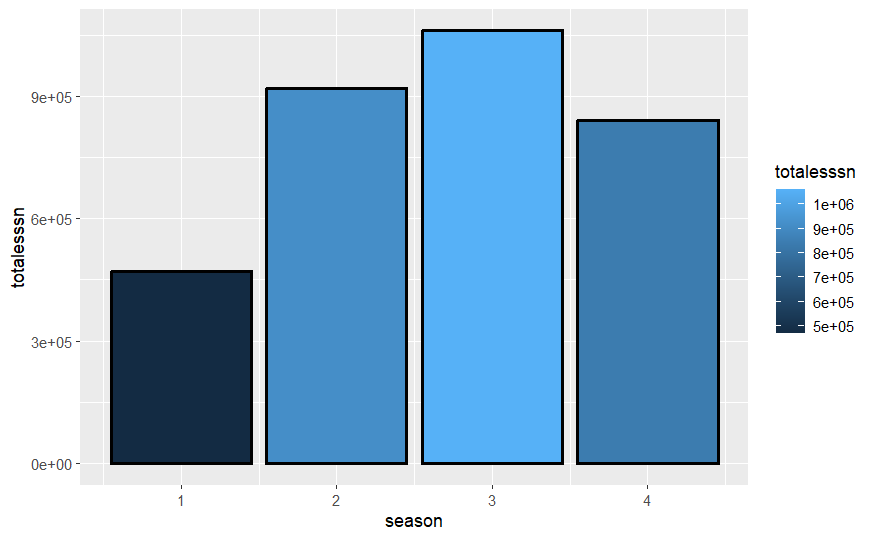

```r
ggplot(MaxSsn, aes(x = season, y = totalesssn, fill = totalesssn)) +
  geom_bar(stat = 'identity', col = 'black', lwd = 1)
```

### 13. Muestre una gráfica de la densidad por hora.

```r
DensHora <- DataBicis %>%
  group_by(hr) %>%
  summarise(rentashoras = sum(cnt), mediarentas = mean(cnt))
```

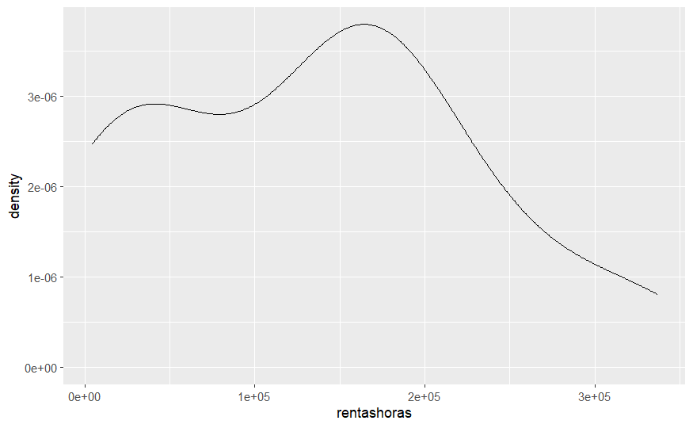

```r
ggplot(data = DensHora, aes(x = rentashoras)) +
  geom_density()
```

```r
DataBiciss <- DataBicis
DataBiciss$hr <- as.character(DataBiciss$hr)
```

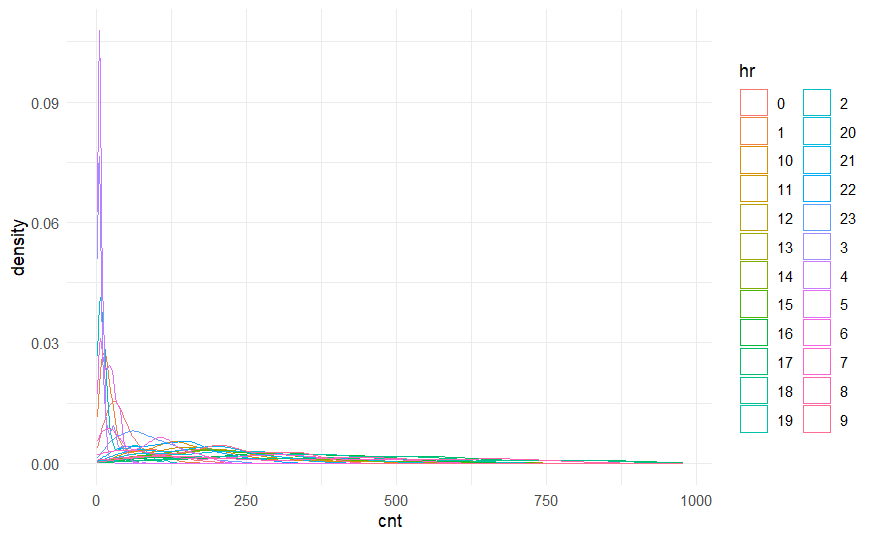

```r
ggplot(data = DataBiciss, aes(x = cnt, col = hr))+
  geom_density(stat = 'density') +
  theme_minimal()
```

### 14. Muestre una gráfica de barras por día del mes como eje x y la cantidad total de alquileres como el eje Y.

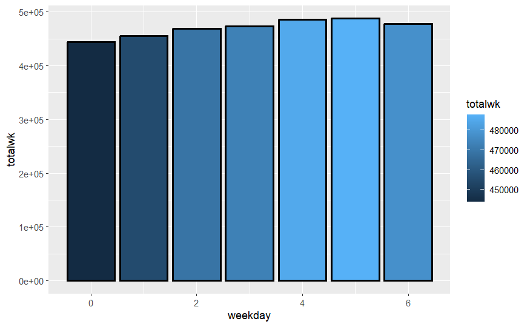

```r
DatosDay <- DataBicis %>%
  group_by(weekday) %>%
  summarise(totalwk = sum(cnt))

ggplot(DatosDay, aes(x = weekday, y = totalwk, fill = totalwk))+
geom_bar(stat = 'identity', col = 'black', lwd = 1)
```

### 15. Muestre una serie temporal (gráfica) con el tiempo (mes-dia-año) como eje de tiempo y la cantidad de alquieleres como eje Y.

```r
BicisDate <- DataBicis %>%
  group_by(dteday) %>%
  summarise(ventadiaria = sum(cnt))
BicisDate$dteday = format(as.Date(BicisDate$dteday), '%Y-%m-%d')
fechas <- strptime(as.character(BicisDate$dteday), "%Y-%m-%d")
BicisDate$dteday <- format(fechas, '%m-%d-%Y')
BicisDate
```

| dteday | ventadiaria |
| --- | --- |
| 01-01-2011 | 985 |
| 01-02-2011 | 801 |
| 01-03-2011 | 1349 |
| 01-04-2011 | 1562 |
| 01-05-2011 | 1600 |
| 01-06-2011 | 1606 |
| 01-07-2011 | 1510 |
| 01-08-2011 | 959 |
| 01-09-2011 | 822 |
| 01-10-2011 | 1321 |

[output cut: 721 more lines]

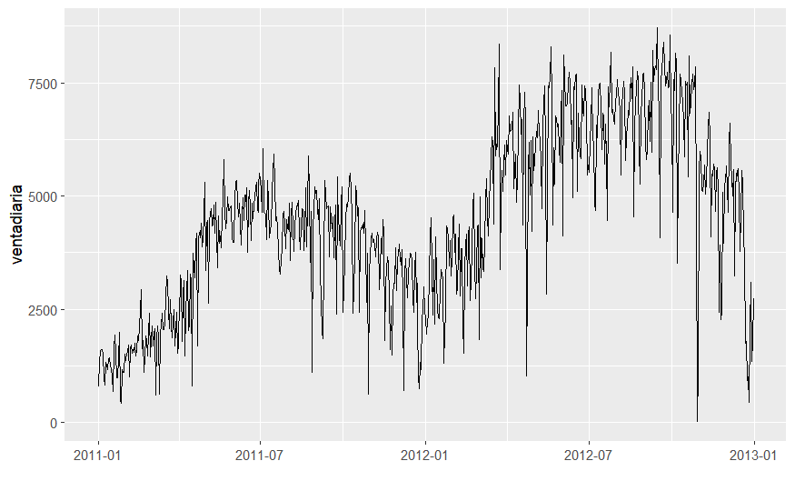

```r
ggplot(data = BicisDate, aes(x = as.Date(dteday,'%m-%d-%Y'), y = ventadiaria)) +
  geom_line() +
  xlab('')
```

### 16. Muestre una gráfica de puntos que relaciones la temperatura como ejer X y la humedad como eje Y.

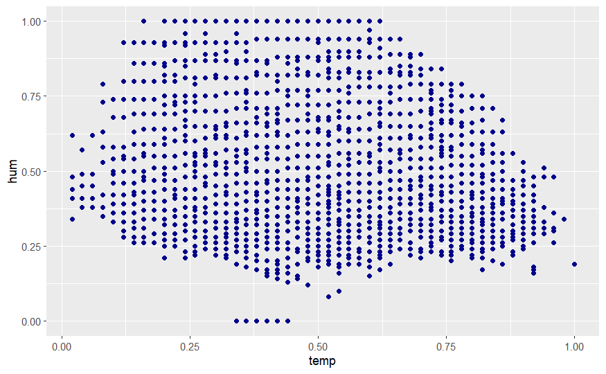

```r
ggplot(data = DataBicis, aes(x = temp, y = hum)) +
  geom_point(col = 'darkblue')
```